# Contraceptive Data Set EDA and Model Fitting

By: Edward Chang and David Cheng

For this project, we will be conducting EDA and model/analysis on a contraceptive data set to analyze a key question: What are the factors that best determine the type of contraceptive used?

```python
# Import packages for this EDA
import pandas as pd
import numpy as np
import seaborn as sns
import matplotlib.pyplot as plt
plt.style.use('ggplot')
```

Data description from: https://archive.ics.uci.edu/ml/datasets/Contraceptive+Method+Choice

## Data Set Information:

This dataset is a subset of the 1987 National Indonesia Contraceptive Prevalence Survey. The samples are married women who were either not pregnant or do not know if they were at the time of interview. The problem is to predict the current contraceptive method choice (no use, long-term methods, or short-term methods) of a woman based on her demographic and socio-economic characteristics.

## Attribute Information:

1. Wife's age (numerical)
2. Wife's education (categorical) 1=low, 2, 3, 4=high
3. Husband's education (categorical) 1=low, 2, 3, 4=high
4. Number of children ever born (numerical)
5. Wife's religion (binary) 0=Non-Islam, 1=Islam
6. Wife's now working? (binary) 0=Yes, 1=No
7. Husband's occupation (categorical) 1, 2, 3, 4
8. Standard-of-living index (categorical) 1=low, 2, 3, 4=high
9. Media exposure (binary) 0=Good, 1=Not good
10. Contraceptive method used (class attribute) 1=No-use, 2=Long-term, 3=Short-term

```python
# Data loading, the data is cleaned, coming with no missing values.
df = pd.read_csv("data.csv")

# Get the value counts (any better way?)
# df.apply(lambda x : print(x.value_counts()), 0)

df_read = df.copy()
# Use human readable column names for visualizations
df_read.columns = ["Wife Age", "Wife Education", "Husband Education",
                   "Number of Children", "Wife Religion", "Wife Work",
                   "Husband Occupation", "Standard of Living", "Media Exposure",
                   "Contraceptive Method"]

# Get indicator variable columns for each non-numerical variable to be used for one-hot encoding
df_dummy = pd.get_dummies(df_read, columns=["Wife Education", "Husband Education",
                                            "Wife Religion", "Wife Work",
                                            "Husband Occupation", "Standard of Living", "Media Exposure"], prefix_sep=" " )
```

# Exploratory Data Analysis

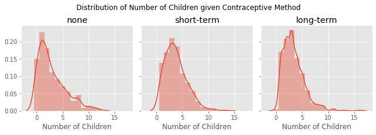

```python
# create tuple for future reference
methods = ('none', 'short-term', 'long-term')
# plot by contraceptive method
p = sns.FacetGrid(data=df_read, col="Contraceptive Method")
# distplots for number of children
p.map(sns.distplot, "Number of Children", bins = np.arange(-0.5, 18.5))
# set title
p.fig.suptitle("Distribution of Number of Children given Contraceptive Method", y = 1.05)
# set sub-titles
for i in range(3):
    p.axes.flatten()[i].set_title(methods[i])
```

The distributions of the number of children given a contraceptive method does not seem to show any significance difference in the number of children birthed between contraceptive methods. We can however see that that method 1 appears to result in a more significant right tail and more distribution to the larger values than the other two plots, which seems to indicate that no contraceptive used tends to mean a more children. These characteristics in the method 1 plot also transfers to method 2, but the rigth tail and distribution shifts are significantly lesser. The third method, long-term contraceptive has the least significant right tail and a tighter spread, indicating that taking long term methods tends to indicate a lesser number of children.

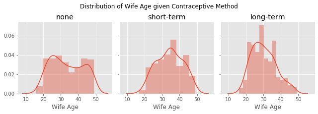

```python
# plot by contraceptive method
p = sns.FacetGrid(data=df_read, col="Contraceptive Method")
# distplots for wife age
p.map(sns.distplot, "Wife Age")
# set title
p.fig.suptitle("Distribution of Wife Age given Contraceptive Method", y = 1.05)
# set sub-titles
for i in range(3):
    p.axes.flatten()[i].set_title(methods[i])
```

These plots indicate that there is significant difference in how wife ages are distributed given a contraceptive method. The first method (no use), there is indication of a slight bimodal distribution in age, with peaks around 25 and 45; overall this method shows slight uniform distribution. As we switch over to longer usages of contraceptive, we see distributions of wife age become unimodal. In the second method (short term use) there is a center of around 35 and the third method has a center around 25~30.

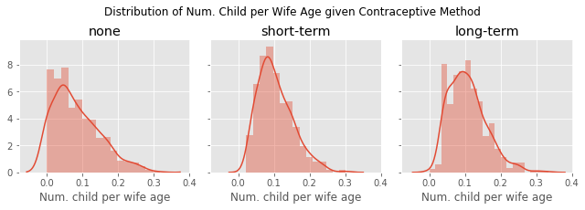

```python
# create new df so that future visualizations are independent of this work
new_df = df_read.copy()
# divide num_child by wife-age
new_df["child_div_age"] = df.num_child / df.wife_age
# facet grid and separate by contraceptive method
p = sns.FacetGrid(data=new_df, col="Contraceptive Method")
# distplots for the new feature per contraceptive method
p.map(sns.distplot, "child_div_age")
# set title
p.fig.suptitle("Distribution of Num. Child per Wife Age given Contraceptive Method",
               y = 1.05)
# set x-axis label
p.set_axis_labels('Num. child per wife age')
# set sub-titles
for i in range(3):
    p.axes.flatten()[i].set_title(methods[i])
```

In this plot, we explore the possibility of using the number of children divided by wife age as a new feature, however, it seems that this is not that effective of a feature compared to if we were to just use the two features that it was formed from. We notice that we lose a lot of the information of the wife age distributions and these new distributions seem to conform more to the number of children distributions, so this indicates that it's probably a good idea to just stick with the former two features.

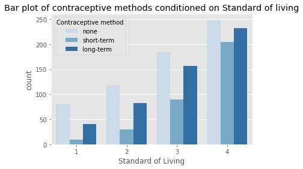

```python
# bar chart for contraceptive method conditioned by standard of living
p = sns.countplot(hue = "Contraceptive Method", x = "Standard of Living", palette=sns.color_palette("Blues", n_colors=3), data=df_read)
# set title
p.set_title("Bar plot of contraceptive methods conditioned on Standard of living")
# set legend
p.legend(('none', 'short-term', 'long-term'), loc='upper left', title='Contraceptive method');
```

This bar chart shows the counts per contraceptive method per standard of living. We can clearly see that there is disproportion between each standard of living; as standard of living increases, it seems that there are more contraceptive users, and short term and long term contraceptive method users approach the proportion of non-contraceptive users.

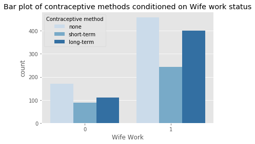

```python
# bar chart for contraceptive method conditioned by wife work status
p = sns.countplot(hue = "Contraceptive Method", x = "Wife Work", palette=sns.color_palette("Blues", n_colors=3), data=df_read)
# set title
p.set_title("Bar plot of contraceptive methods conditioned on Wife work status")
# set legend
p.legend(('none', 'short-term', 'long-term'), loc='upper left', title='Contraceptive method');
```

This bar chart is pretty self explanatory since there aren't many combinations to look at. There is a greater proportion of long-term contraceptive users in the non-working sample than the working sample, but the proportion in short-term usage stays similar between the two groups.

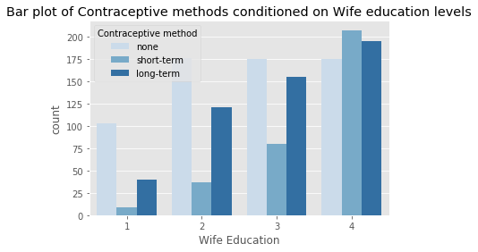

```python
# bar chart for contraceptive method conditioned by wife education levels
p = sns.countplot(hue = "Contraceptive Method", x = "Wife Education", palette=sns.color_palette("Blues", n_colors=3), data=df_read)
# set title
p.set_title("Bar plot of Contraceptive methods conditioned on Wife education levels")
# set legend
p.legend(('none', 'short-term', 'long-term'), loc='upper left', title='Contraceptive method');
```

We see that a wife's education is pretty substantial on determining usage of contraceptives. As the education level of a wife increases, we see a very large increase in the usages of contraceptives and also see short-term usage top long-term and no contraceptives used. One surprising thing that we see from this plot is that contraceptive methods, both short term and long term, both dominate no usage at high education level, which is something that we haven't seen at all in the rst of the plots.

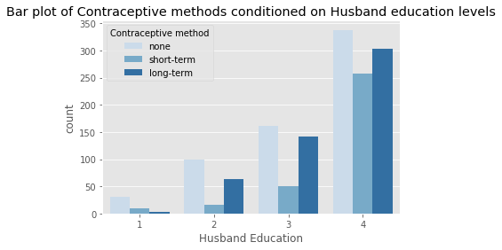

```python
# bar chart for contraceptive method conditioned by husband education level
p = sns.countplot(hue = "Contraceptive Method", x = "Husband Education", palette=sns.color_palette("Blues", 3), data = df_read)
# set title
p.set_title("Bar plot of Contraceptive methods conditioned on Husband education levels")
# set legend
p.legend(('none', 'short-term', 'long-term'), loc='upper left', title='Contraceptive method');
```

This plot is not that interesting as we've already seen a similar pattern in the standard of living plot. A substantial difference between these two plots is that we see extremely low usage of contraceptive methods at education level 1.

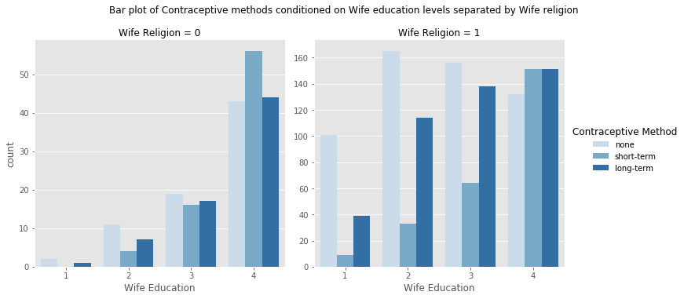

```python
# bar chart for contraceptive method conditioned by wife education level then by wife religion
p = sns.catplot(hue="Contraceptive Method", x="Wife Education", col="Wife Religion", palette=sns.color_palette("Blues", n_colors=3), sharey=False, data=df_read, kind="count", edgecolor=(0,0,0,0), linewidth=2)
# set title
p.fig.suptitle("Bar plot of Contraceptive methods conditioned on Wife education levels separated by Wife religion", y=1.05)
# set sub-titles
for t, l in zip(p._legend.texts,('none', 'short-term', 'long-term')):
    t.set_text(l)
```

We created a plot that conditioned on more features and got some interesting results. We notice that there is an incredibly small sample of non-islamic, low-education women who use no contraceptive method. Such a small sample may bring up issues in our model fitting since small samples aren't that reliable to fit models that can accurately predict using test data. Based on this, we could also assume that there are other similar small samples of women in our data set if we further condition on more variables; in fact, we already saw this small sample issue occuring in the plots that we made previously, so there can be some serious overfitting issues in our models that are fitted later in this notebook.

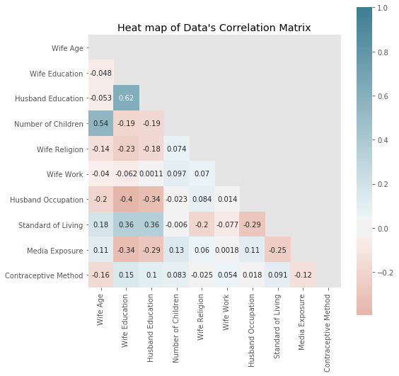

```python
# Correlation matrix heatmap
# set figure size
plt.figure(figsize = (8, 8))
# create a mas for the entries above and on the diagonal
mask = np.triu(np.ones_like(df.corr(), dtype=np.bool))
# create heatmap
hm = sns.heatmap(df_read.corr(), cmap = sns.diverging_palette(20, 220, n=200),
            square = True, center = 0, mask=mask, annot=True)
# Set title
hm.set_title("Heat map of Data's Correlation Matrix");
```

As a disclaimer, since we are dealing with categorical variables, it is very understandable that this visualization does not reflect the true relationships, but we will continue on from this discrepancy since we will still get some limited information from this visualization. From this heatmap, it appears that, pairwise, little to no correlation can be found with the other variables and the contraceptive method. In regards to the number of children, we can see that the wife's age seems to be a big factor, with a relatively high correlation of 0.54. We can also see a high correlation between husband and wife education, which might suggest we are not using both variables in a model, but this is expected as people with education tend to meet other people with education. Low correlation between variables is seen between most variables. To confirm suspicions that this heat map creates, it would be better to create a clustered heatmap with row annotations to clearly identify relationships.

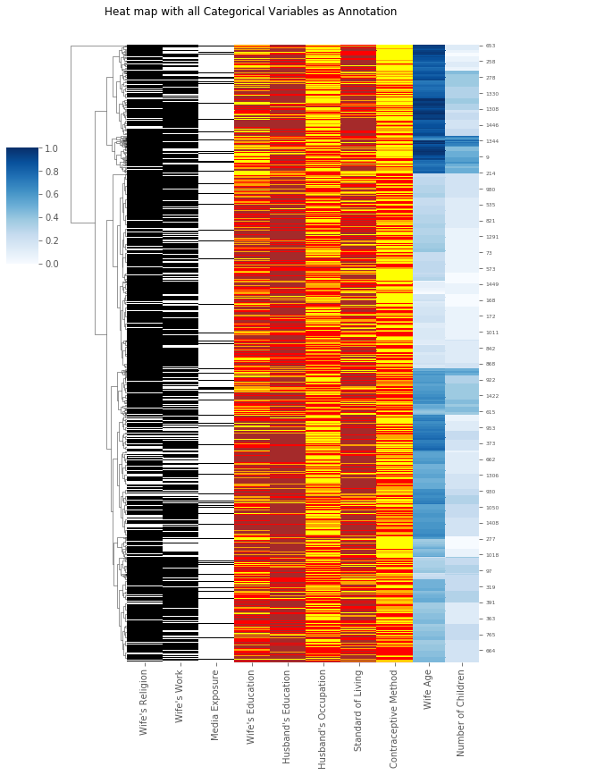

```python
# Slight credit for making this part:
# https://python-graph-gallery.com/405-dendrogram-with-heatmap-and-coloured-leaves/
from mpl_toolkits.axes_grid1 import make_axes_locatable
import matplotlib as mpl
# Take out the numerical data
heat_df = df[['wife_age', 'num_child']]
# Create color palette for the binary data
palette_binary = dict(zip([0,1], ['white', 'black']))
# Create color palette for the categorical data
palette_mult = dict(zip([1,2,3,4], ['yellow', 'orange', 'red', 'brown']))
# Map binary color palette
colors_binary = df[['wife_religion', 'wife_work', 'media_exposure']].apply(
func = lambda x : x.map(palette_binary), axis = 1)
# Map categorical color palette
colors_mult = df[['wife_education', 'husband_education', 'husband_occupation', 'standard_living', 'contraceptive']].apply(
func = lambda x : x.map(palette_mult), axis = 1)
# Create color data frame for row annotation
colors = pd.concat(
    [colors_binary.reset_index(drop = True),
    colors_mult.reset_index(drop = True)], axis = 1)
colors.columns = ["Wife's Religion", "Wife's Work", "Media Exposure",
                     "Wife's Education", "Husband's Education",
                     "Husband's Occupation", "Standard of Living",
                     "Contraceptive Method"]
# Create a clustered heat map for the data
# We can remove column clustering because there's only two variables to
# cluster on if we do
cm = sns.clustermap(heat_df, cmap = "Blues", standard_scale = 1, row_colors = colors,
                    col_cluster = False,
              cbar_kws={"shrink": 0.5})
# Various axes manipulation to change the set up of the heatmap
hm = cm.ax_heatmap.get_position()
row = cm.ax_row_dendrogram.get_position()
row_col = cm.ax_row_colors.get_position()
plt.setp(cm.ax_heatmap.yaxis.get_majorticklabels(), fontsize=6)
cm.ax_row_dendrogram.set_position([row.x0+.1, row.y0, row.width*.5, row.height*1.5])
cm.ax_heatmap.set_position([row.width*.5+row_col.width*2+row.x0+.1, hm.y0, hm.width*.2, hm.height*1.5])
cm.ax_row_colors.set_position([row_col.x0 - row.width*.5+.1, row_col.y0, row_col.width*2, row_col.height*1.5])
cm.ax_heatmap.set_xticklabels(['Wife Age', 'Number of Children'], rotation=90)
cbar1 = cm.cax
# Set title
cm.fig.suptitle("Heat map with all Categorical Variables as Annotation", x=.4, y=1.2);
# This plot may have messed up positioning on other machines, but we have made sure it is as expected on the jupyterlab environment on the data100 datahub servers
```

A heatmap with row clustering was created for this visualization. Only the numerical variables (wife age and number of children) where accounted for in the clustering process and the categorical variables are included in the heatmap as row annotations. Black white coloring denotes the binary variables with white indicating level 0 and black indicating level 1. Yellow, orange, red, brown colouring denotes categorical variables with at most 4 levels, each indicating levels 1, 2, 3, 4 respectively.

With just clustering done on the numerical variables, we see some significant banding with a portion of the observations; for young wifes, there are a lesser number of children; the converse is not true. We however, expect this result, since younger means lesser opportunity/time to have children. Other than this, it is hard to conclude other relations with the categorical variables from this clustered heatmap with row annotation since there is little that we can analyze at a glance.

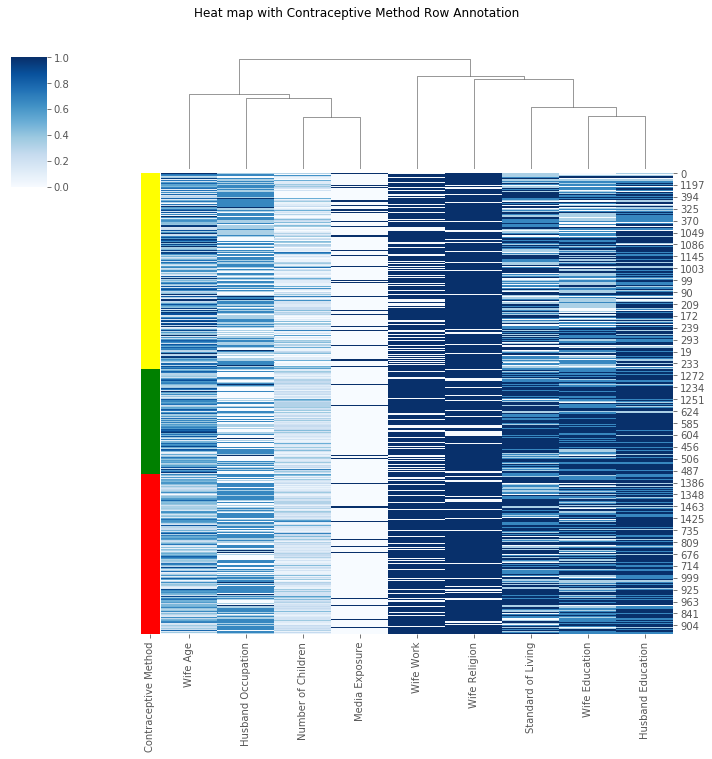

```python
###### also messed up size
# Create a data frame with the contraceptive method column removed
heat_df = df_read.sort_values("Contraceptive Method").drop("Contraceptive Method", 1)
# Create color palette for the categorical data
palette_mult = dict(zip([1,2,3], ['yellow', 'green', 'red']))
# Create series with colors mapped to contraceptive method
colors_mult = df_read.sort_values("Contraceptive Method")['Contraceptive Method'].map(palette_mult)
# Create a clustered heat map for the data
# We can remove column clustering because there's only two variables to
# cluster on if we do
cm = sns.clustermap(heat_df, cmap = "Blues", standard_scale = 1, row_colors = colors_mult, row_cluster=False,
                    cbar_kws={"shrink": 0.5})
# Set title of the figure
cm.fig.suptitle("Heat map with Contraceptive Method Row Annotation", y=1.05);
# This plot may have messed up positioning on other machines, but we have made sure it is as expected on the jupyterlab environment on the data100 datahub servers
```

This time, a heatmap was created with no row clustering and only column clustering. All variables expect for the contraceptive method were included in this as to see how the categorical variables would be clustered (although we are interpreting the categorical variables as numerical in this application of the heatmap, we can still see relationships by standardizing the variables and looking at the color shifts; the main purpose of this heatmap is to check see if there are noticeable relationships that relate directly to the contraceptive method). One remarkable thing that we can see from this map is the banding with the contraceptive methods. Husband education, wife education, standard of living all seem to show that higher levels/higher values of these variables tend to mean that short-term usage contraceptives were used and there seems to be good media exposure and slightly more middle-age women in this group. Other than this observation, we see that the other variabbles seem to take on random values and won't give much information in what type of contraceptive method is used. Over all from these heatmaps, the randomness of most of these observations confirms why our correlation matrix shows little correlations between variables; there is little pattern that we can observe among observations with similar traits. As for associations with between variables, our previous observation in the correlation matrix heatmap about husband and wife education levels is fairly represented in this heatmap since we can see that they were clustered together and seem show some one-to-one relationship. In contrast to the correlation matrix, this shows some other relationships that weren't evident through the clustered columns. We see that the standard of living is closely related to the education levels of the wife and husband and the wife's religion and work status are further related to those. Although we do see clustering in the 4 variables left, there does not seem to be much conclusions we can make at a glance since things seem to be more evenly spread out with no apparent relationships.

# Modeling

```python
import sklearn
import sklearn.model_selection as ms
import sklearn.linear_model
from sklearn.linear_model import LogisticRegression
from sklearn import metrics

# current categorical features being used in our models
features = ['wife_religion', 'wife_work', 'husband_occupation', 'husband_education', 'standard_living', 'media_exposure', 'wife_education']
# current categorical features being excluded in our models
exclude = []

def splitDummies(df, exclude):
    """
    Split a data frame with all the features in our given data into the response and explanatory variables,
    and one-hot encode every categorical variable in the response.
    This also excludes features from the resulting X df that aren in the global EXCLUDE list
    """
    X = pd.get_dummies(df.drop(["contraceptive"] + exclude, axis=1), columns=features)
    y = df.contraceptive
    return X, y

df = pd.read_csv("data.csv")

# split our data into train and test sets
train, test = ms.train_test_split(df, test_size=0.2, random_state=1)

# further split our sets into X and y sets with dummy variables
X_train, y_train = splitDummies(train, exclude)
X_test, y_test = splitDummies(test, exclude)

# Logistic Regression

print('Logistic Regression')
lr_model = LogisticRegression(max_iter=4000, solver="lbfgs")

lr_model.fit(X_train, y_train)


lr_train_accuracy = np.mean(lr_model.predict(X_train) == y_train)
lr_train_cross_accuracy = np.mean(ms.cross_val_score(lr_model, X_train, y_train, cv=5))
lr_test_accuracy = np.mean(lr_model.predict(X_test) == y_test)
print("Train accuracy:", round(lr_train_accuracy * 100, 2))
print("Cross validation accuracy:", round(lr_train_cross_accuracy * 100, 2))
print("Test accuracy:", round(lr_test_accuracy * 100, 2))

# Decision tree

print('\nDecision Tree')
from sklearn import tree
dt_model = tree.DecisionTreeClassifier(max_depth = 6)
dt_model.fit(X_train, y_train)

dt_train_accuracy = np.mean(dt_model.predict(X_train) == y_train)
dt_train_cross_accuracy = np.mean(ms.cross_val_score(dt_model, X_train, y_train, cv=5))
dt_test_accuracy = np.mean(dt_model.predict(X_test) == y_test)
print("Train accuracy:", round(dt_train_accuracy * 100, 2))
print("Cross validation accuracy:", round(dt_train_cross_accuracy * 100, 2))
print("Test accuracy:", round(dt_test_accuracy * 100, 2))

# Naive model
print('\nNaive')
print("Test accuracy:", round(sum(y_test == 1) / len(y_test) * 100, 2))
# As previously mentioned, the most popular contraceptive method is no contraceptive, of which 629 out of 1473 women in the dataset has done.
# If a naive model were to predict no contraceptive always, it would have a 43.73% accuracy if used on the training data.
# Both models seem to not fair much better than the naive model.
```

```
Logistic Regression
Train accuracy: 52.04
Cross validation accuracy: 50.42
Test accuracy: 54.24

Decision Tree
Train accuracy: 60.7
Cross validation accuracy: 52.46
Test accuracy: 56.95

Naive
Test accuracy: 43.73
```

The logistic regression model achieves a 54.24% test accuracy while the decision tree model achieves a 56.95% test accuracy with all of the attributes besides contraceptive method use fed in. These model accuracies are better than a naive model that just indiscriminately selects the highest count contraceptive method, no contraceptive, that would achieve a 43.73% accuracy with the same test set. Additionally, each feature was individually selected for both models and found that the number of children variable using the decision tree model had the highest test accuracy out of any single feature and model combination.

```python
#These are the test accuracies for each individual feature, with the left numbers from logistic regression and the right being from decision tree
single_attr = [['wife_age', 44.07, 41.02], ['wife_education', 41.69, 45.76], ['wife_religion', 43.73, 42.71], ['husband_education', 43.73, 43.73], ['num_child', 41.02, 47.8], ['wife_work', 43.73, 43.73], ['husband_occupation', 42.37, 42.37], ['standard_living', 43.73, 43.73], ['media_exposure', 43.73, 43.73]]
single_attr
```

The above accuracies were obtained through manually selecting each individual feature and applying one hot encoding if neccessary.

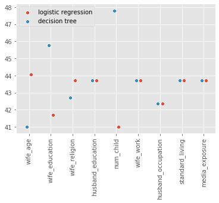

```python
# plot logistic regression results
sns.scatterplot(x=np.arange(0.1, 9, 1), y=[x[1] for x in single_attr], label='logistic regression');
# plot decision tree results
sns.scatterplot(x=np.arange(-0.1, 8, 1), y=[x[2] for x in single_attr], label='decision tree');
# label the x-axis
plt.xticks(range(9), labels=[x[0] for x in single_attr], rotation=90);
# change legend posiiton
plt.legend(loc = 'upper left');
```

As shown, it seems that, using a single variable, number of children is the best predictor than the others for the decision tree model. Oddly enough, that variable is also the worst predictor for the logistic regression model.